# Probability distributions

## The QQ-plot

The qq-plot compares the quantiles of two distributions.

Quantiles are the inverse of the cumulative distribution, i.e., the `qnorm` function is the inverse of `pnorm`:

You can use `pnorm` to ask for the probability of seeing a value of `−2` or smaller:

```r
pnorm(q = -2,mean=0, sd=2)
```

```
[1] 0.1586553
```

Then you can use qnorm to ask that is the value for which 15% of the other values are smaller. Here, I demonstrate this by plugging the result into the pnorm function into the qnorm function:

```r
qnorm(p= pnorm(q = -2,mean=0, sd=2), mean=0, sd=2)
```

```
[1] -2
```

Let’s compare the quantiles of the simulated frog sizes to the theoretical quantiles of a normal distribution. There are specialized functions for qq-plots, so we don’t have to calculate the theoretical values by hand:

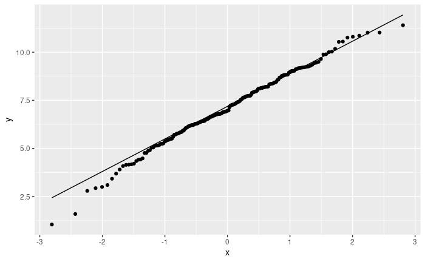

```r
data.frame(frog_sizes) %>%
  ggplot(aes(sample=frog_sizes)) +
  geom_qq() +
  geom_qq_line()
```

By default, the `geom_qq` function assumes that we compare to a standard normal distribution.

Let’s set up a qq-plot where we compare to a Poisson distribution:

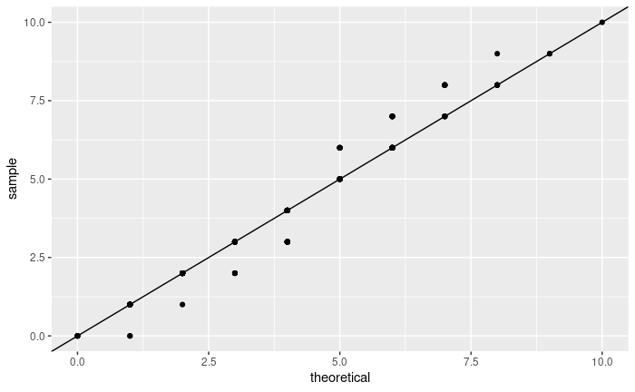

This fit looks better. We can still argue whether a qq-plot is the best representation for a Poisson fit, because due to the distribution’s discreteness, many data points end up on the exact same spot in the plot (overplotting). Thus, we loose information in this visualization.

## One fits all - fitdistrplus package

If you want a quick overview, you can use the fitdistrplus package, which produces a series of plots.

Suppose you fit the frog counts to a normal distribution:

```r
# install.packages("fitdistrplus")
library(fitdistrplus)
my_fit <- fitdist(frog_counts, dist = "norm")
my_fit # gives you the parameter estimates
```

```
Fitting of the distribution ' norm ' by maximum likelihood
Parameters:
```

|  | estimate | Std. Error |
| --- | --- | --- |
| mean | 3.830000 | 0.1495176 |
| sd | 2.114498 | 0.1057248 |

[figure not shown]

With some practice, this plot quickly allows you to see that you are comparing discrete data to a continuous distribution. Also, the QQ-plot doesn’t really give a straight line and the histogram seems to be skewed to the left, compared to theory.

**Exercise:** What does it look like if you fit the frog_counts to a Poisson instead?

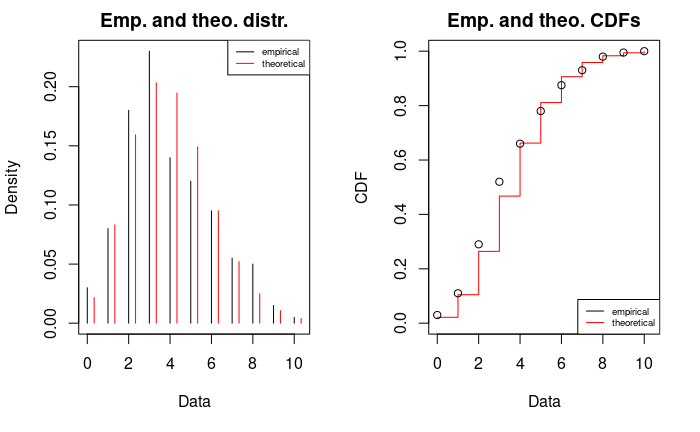

```r
library(fitdistrplus)
my_fit <- fitdist(frog_counts, dist = "pois")
plot(my_fit)
```